# Assignment 4: Movie Review Analysis [50 Pt]

In this assignment, we will build a recurrent neural network to work with sequential text data, specificially, movie review data to identify the reviewer sentiment. In the process of completing this assignment, you will:

1. Clean and process text data for machine learning.
2. Perform tokenization of text data.
3. Understand and implement a word-level recurrent neural network.
4. Implement batching of text data using a DataLoader before training a recurrent neural network.
5. Understand how to apply pretrained models for transfer learning in natural language processing projects.

### What to submit

Submit an HTML file containing all your code, outputs, and write-up from parts A and B. You can produce a HTML file directly from Google Colab. The Colab instructions are provided at the end of this document.

**Do not submit any other files produced by your code.**

Include a link to your colab file in your submission.

Please use Google Colab to complete this assignment. If you want to use Jupyter Notebook, please complete the assignment and upload your Jupyter Notebook file to Google Colab for submission.

## Colab Link

Include a link to your Colab file here. If you would like the TA to look at your Colab file in case your solutions are cut off, **please make sure that your Colab file is publicly accessible at the time of submission.**

```python
# TO BE COMPLETED

https://colab.research.google.com/drive/1uBXpRxjK9nAPFjIGBZ868a6cdFx4CWPr?usp=sharing
```

# PART A - Sentiment Analysis

In this part we will construct a world-level LSTM model for identifying positive and negative reviews. This will be done in a similar way to what was shared in the preparation code for Assignment 4.

```python
# load standard modules/libraries
import pandas as pd
import numpy as np
import matplotlib.pyplot as plt
import seaborn as sns
from sklearn.model_selection import train_test_split

# load special modules/libraries
import os
import warnings
import nltk
from nltk.corpus import stopwords
nltk.download('stopwords')

from collections import Counter
import string
import re
from tqdm  import tqdm

# load pytorch modules/libraries
import torch
import torch.nn as nn
import torch.nn.functional as F
import torch.optim as optim
from torch.utils.data import TensorDataset,DataLoader
```

## Part 1. Data Cleaning [5 pt]

We will be using the "IMDB Movie Review Dataset" provided on the course website. Download "IMDB Dataset.csv" into your Colab workspace.

### Part (i) [1pt EXPLORATORY]

Open up the file in Python, and examine some examples of positive and negative reviews. Comment on the quality of the data and any challenges you foresee in working with these data. Pick one example of a positive review and one of a negative review to support your comments.

```python
# download IMDB review data

# load dataset
df = pd.read_csv("IMDB Dataset.csv")

# process into data and labels
X = df['review'].values
y = df['sentiment'].values
```

```python
# TO BE COMPLETED

print(f"X type {type(X)}")
print(f"y type {type(y)}")
print(f"number of reviews: {len(X)}")
for i in range(0,5):
  print(f"sentiment: {y[i]}")
  print(f"n of word in review: {len(X[i])}")
  print(f"review: {X[i]}")
```

```
X type <class 'numpy.ndarray'>
y type <class 'numpy.ndarray'>
number of reviews: 50000
sentiment: positive
n of word in review: 1761
review: One of the other reviewers has mentioned that after watching just 1 Oz episode you'll be hooked. They are right, as this is exactly what happened with me.<br /><br />The first thing that struck me about Oz was its brutality and unflinching scenes of violence, which set in right from the word…
sentiment: positive
n of word in review: 998
review: A wonderful little production. <br /><br />The filming technique is very unassuming- very old-time-BBC fashion and gives a comforting, and sometimes discomforting, sense of realism to the entire piece. <br /><br />The actors are extremely well chosen- Michael Sheen not only "has got all the …
sentiment: positive
n of word in review: 926
review: I thought this was a wonderful way to spend time on a too hot summer weekend, sitting in the air conditioned theater and watching a light-hearted comedy. The plot is simplistic, but the dialogue is witty and the characters are likable (even the well bread suspected serial killer). While some…
sentiment: negative
n of word in review: 748
review: Basically there's a family where a little boy (Jake) thinks there's a zombie in his closet & his parents are fighting all the time.<br /><br />This movie is slower than a soap opera... and suddenly, Jake decides to become Rambo and kill the zombie.<br /><br />OK, first of all when you're goi…
sentiment: positive
n of word in review: 1317
review: Petter Mattei's "Love in the Time of Money" is a visually stunning film to watch. Mr. Mattei offers us a vivid portrait about human relations. This is a movie that seems to be telling us what money, power and success do to people in the different situations we encounter. <br /><br />This bei…
```

```python
#check for more negatives reviews
[print(X[i] + "\n") for i, s in enumerate(y[:10]) if s == "negative"]
```

```
Basically there's a family where a little boy (Jake) thinks there's a zombie in his closet & his parents are fighting all the time.<br /><br />This movie is slower than a soap opera... and suddenly, Jake decides to become Rambo and kill the zombie.<br /><br />OK, first of all when you're going to ma…

This show was an amazing, fresh & innovative idea in the 70's when it first aired. The first 7 or 8 years were brilliant, but things dropped off after that. By 1990, the show was not really funny anymore, and it's continued its decline further to the complete waste of time it is today.<br /><br />It…

Encouraged by the positive comments about this film on here I was looking forward to watching this film. Bad mistake. I've seen 950+ films and this is truly one of the worst of them - it's awful in almost every way: editing, pacing, storyline, 'acting,' soundtrack (the film's only song - a lame coun…
```

```
[None, None, None]
```

```python
'''
PROVIDE YOUR ANSWER BELOW

-50000 can be computational expensive
-review are bigger than tweets, training will be slower
-Grammar in the sentences is not perfect and spelling errors may be provoke
  a worst training


'''
```

```
'\nPROVIDE YOUR ANSWER BELOW\n\n-50000 can be computational expensive\n-review are bigger than tweets, training will be slower\n-Grammar in the sentences is not perfect and spelling errors may be provoke \n  a worst training\n\n\n'
```

### Part (ii) [1pt EXPLORATORY]

Perform summary statistics on the dataset. What is the average character length of a review? What are the lengths of the longest and shortest reviews?

How many positive reviews and negative reviews are there. Generate a histogram to compare the average character length for positive and negative reviews. Comment on the differences in positive and negative reviews and how that may affect the model you will be using later.

```
average of character lenght of reivew: 1309.43102
Max lenght for character: 13704
Min lenght for character: 32
Number of positives: 25000
Number of negatives: 25000
```

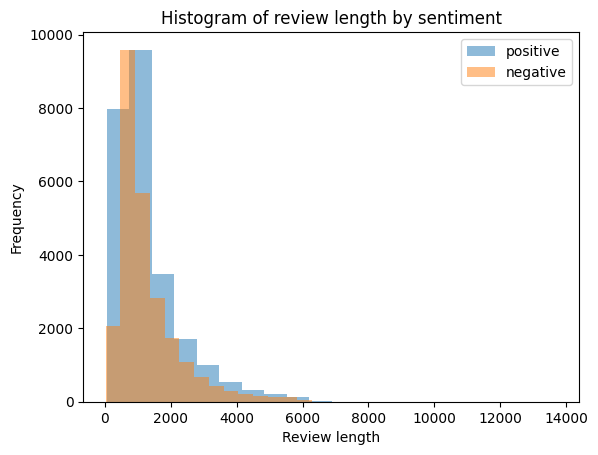

```python
# TO BE COMPLETED

#average of char len in reviews
#len longest and short
#how many positive and negative reviews (histo to compare len in positives
# len in negatives)

#calculate char len for each review
len_reviews = np.array([len(review) for review in X])
#average
avr_char = np.mean(len_reviews)
print(f"average of character lenght of reivew: {avr_char}")
#max character lenght
max_char = np.max(len_reviews)
#min character lenght
min_char = np.min(len_reviews)
#number of positives and negatives

positive_review = len_reviews[y == 'positive']
negative_review = len_reviews[y == 'negative']

print(f"Max lenght for character: {max_char}")
print(f"Min lenght for character: {min_char}")

print(f"Number of positives: {len(positive_review)}")
print(f"Number of negatives: {len(negative_review)}")

import matplotlib.pyplot as plt

plt.hist(positive_review, bins=20, alpha=0.5, label="positive")
plt.hist(negative_review, bins=20, alpha=0.5, label="negative")
plt.xlabel("Review length")
plt.ylabel("Frequency")
plt.title("Histogram of review length by sentiment")
plt.legend()
plt.show()
```

```python
'''
PROVIDE YOUR ANSWER BELOW


General observations :

- There char from 32 to 13704 char, but we can see in the plot that the
  majority are "short" among the 1000 chars (1309 average because of outliers)
- There are the same amount of positives and negatives reviews


Observations positive vs negative:

- In average, the positive reviews are slighly longer than negative reviews

The difference in length may affect the input for our model, I think it will be
neccesary to do a preprocessing step to create same sized batches, maybe
padding shorter sequences with zero inputs.


'''
```

### Part (iii) [1pt EXPLORATORY]

The following helper code will be used to process the data before we can train our LSTM model. In point form comment on what processing steps are performed in the code provided below and why these steps are necessary or beneficial to training and LSTM.

```python
X[0]
```

```
"One of the other reviewers has mentioned that after watching just 1 Oz episode you'll be hooked. They are right, as this is exactly what happened with me.<br /><br />The first thing that struck me about Oz was its brutality and unflinching scenes of violence, which set in right from the word GO. Tr…
```

```python
def preprocess_string(str1):
    # remove all non-word characters excluding number and letters
    str1= re.sub(r"[^\w\s]",'',str1)
    # remove all whitespace with no space
    str1= re.sub(r"\s",'',str1)
    # replace digits with no space
    str1= re.sub(r"\d",'',str1)
    return str1

def preprocess_sentence(sen1):
    word_list=[]
    stop_word = set(stopwords.words("english"))
    for word in sen1.lower().split():
        word = preprocess_string(word)
        if word not in stop_word and word!='':
            word_list.append(word)
    return word_list

def get_stoi(data):
    word_list=[]
    for review in data:
        word_list.extend(preprocess_sentence(review))
    corpus = Counter(word_list)
    print(corpus.get)
    # sorting on the basis of most common words
    corpus_ =sorted(corpus,key= corpus.get,reverse=True)[:1000]
    # creating a dict
    stoi =  {ch:i+1 for i,ch in enumerate(corpus_)}
    return stoi

def tokenize(data, labels, stoi):
    # tokenize
    data_encoded = []
    for review in data:
        data_encoded.append([stoi[word] for word in preprocess_sentence(review)
                                     if word in stoi.keys()])

    labels_encoded = [1 if label =='positive' else 0 for label in labels]

    return np.array(data_encoded), np.array(labels_encoded)

def padding_(sentences, seq_len):
    features = np.zeros((len(sentences), seq_len),dtype=int)
    for ii, review in enumerate(sentences):
        if len(review)!=0:
            features[ii, -len(review):] = np.array(review)[:seq_len]

    return features
```

```python
'''
PROVIDE YOUR ANSWER BELOW


These functions will help in the preprocessing of our model input, cleaning unnecessary
words, and creating same sized batches.

preprocess_string: will remove non words chars, digits and white spaces from
string

preprocess_sentence: will remove stopwords which are innecesary

get_stoi: map words to index

tokenize: creates a data_encoder and label for each input

padding: his function pads sequences with zeros to ensure uniform length for model input.




'''
```

### Part (iv) [1pt EXPLORATORY]

Split the dataset into `train`, `valid`, and `test`. Use a 60-20-20 split. Then apply the above processing steps to prepare your data for training.

Set the padding of the reviews to 500.

```python
# TO BE COMPLETED
seq_length = 500

# train (60%), temp 40%: validation (20%), and test (20%) sets

X_train, X_temp, y_train, y_temp = train_test_split(X, y, test_size=0.4, random_state=42)
X_val, X_test, y_val, y_test = train_test_split(X_temp, y_temp, test_size=0.5, random_state=42)

# generate word-to-index mapping (stoi)
stoi = get_stoi(X_train)

#tokenize and pad the data for training, validation, and test sets
X_train_encoded, y_train_encoded = tokenize(X_train, y_train, stoi)
X_val_encoded, y_val_encoded = tokenize(X_val, y_val, stoi)
X_test_encoded, y_test_encoded = tokenize(X_test, y_test, stoi)

# Apply padding to ensure uniform length
X_train_padded = padding_(X_train_encoded, seq_length)
X_val_padded = padding_(X_val_encoded, seq_length)
X_test_padded = padding_(X_test_encoded, seq_length)
```

```
<built-in method get of Counter object at 0x7f794d7adf30>
```

### Part (v) [1pt EXPLORATORY]

Create a DataLoader that will allow you to load the training and validation data in mini-batches. Then generate a dataset of batch size of 16 to verify that the DataLoader works as intended.

```python
# TO BE COMPLETED

# Define a custom Dataset class to load the data
class CustomDataset():
    def __init__(self, X, y):
        self.X = X
        self.y = y

    def __len__(self):
        return len(self.X)

    def __getitem__(self, idx):
        return self.X[idx], self.y[idx]

# Create Dataset instances for training and validation
train_dataset = CustomDataset(X_train_padded, y_train_encoded)
val_dataset = CustomDataset(X_val_padded, y_val_encoded)
test_dataset = CustomDataset(X_test_padded, y_test_encoded)
# Define batch size
batch_size = 16

# Create DataLoader instances for training and validation
train_loader = DataLoader(train_dataset, batch_size=batch_size, shuffle=True)
val_loader = DataLoader(val_dataset, batch_size=batch_size)
test_loader = DataLoader(test_dataset, batch_size=batch_size)

# Verify the DataLoader works by iterating over a batch of data
for batch_idx, (data, labels) in enumerate(train_loader):
    # Printing the batch index and shape of data and labels for verification
    print(f"Batch {batch_idx + 1}:")
    print(f"Data shape: {data.shape}")
    print(f"Labels shape: {labels.shape}")
    break  # Break after the first batch for demonstration purposes
```

```
Batch 1:
Data shape: torch.Size([16, 500])
Labels shape: torch.Size([16])
```

## Part 2. Model Building [2pt MODEL]

Build a recurrent neural network model, using an architecture of your choosing. Use one or more fully-connected layers to make the prediction based on your recurrent network output.

Instead of using the RNN output value for the final token, another often used strategy is to max-pool over the entire output array. That is, instead of calling something like:

```
out, _ = self.rnn(x)
self.fc(out[:, -1, :])
```

where `self.rnn` is an `nn.RNN`, `nn.GRU`, or `nn.LSTM` module, and `self.fc` is a fully-connected layer, we use:

```
out, _ = self.rnn(x)
self.fc(torch.max(out, dim=1)[0])
```

This works reasonably in practice. An even better alternative is to concatenate the max-pooling and average-pooling of the RNN outputs:

```
out, _ = self.rnn(x)
out = torch.cat([torch.max(out, dim=1)[0],
                 torch.mean(out, dim=1)], dim=1)
self.fc(out)
```

We encourage you to try out all these options. The way you pool the RNN outputs is one of the "hyperparameters" that you can choose to tune later on.

```python
# Set device to GPU if available
device = torch.device("cuda" if torch.cuda.is_available() else "cpu")
```

```python
#based on pre4A
class SentimentRNN(nn.Module):
    def __init__(self,no_layers,vocab_size,hidden_dim,embedding_dim,drop_prob=0.3):
        self.name = "SentimentRNN"
        super(SentimentRNN,self).__init__()

        self.no_layers = no_layers
        self.vocab_size = vocab_size
        self.output_dim = 1
        self.hidden_dim = hidden_dim

        # LSTM layers
        self.embedding = nn.Embedding(vocab_size, embedding_dim)

        #lstm
        self.lstm = nn.LSTM(input_size=embedding_dim,hidden_size=self.hidden_dim,
                           num_layers=no_layers, batch_first=True)

        # linear and sigmoid layer
        self.fc = nn.Linear(self.hidden_dim, output_dim)
        self.s = nn.Sigmoid()
        # dropout layer
        self.dropout = nn.Dropout(drop_prob)

    def forward(self,x,hidden):
        # Apply embedding layer
        batch_size = x.size(0)
        embeds = self.embedding(x)
        # LSTM layer
        lstm_out, hidden = self.lstm(embeds, hidden)

        lstm_out = lstm_out.contiguous().view(-1, self.hidden_dim)

        # dropout and fully connected layer
        out = self.dropout(lstm_out)
        # Fully connected layer
        out = self.fc(out)

        # Sigmoid activation for binary classification
        sig_out = self.s(out)
        # reshape to be batch_size first
        sig_out = sig_out.view(batch_size, -1)
        # Get the output from the last time step
        sig_out = sig_out[:, -1]
        # return last sigmoid output and hidden state
        return sig_out, hidden



    def init_hidden(self, batch_size):
        # cell state of LSTM
        h0 = torch.zeros((self.no_layers,batch_size,self.hidden_dim)).to(device)
        c0 = torch.zeros((self.no_layers,batch_size,self.hidden_dim)).to(device)
        hidden = (h0,c0)
        return hidden
```

## Part 3. Training [3 pt]

### Part (i) [1pt MODEL]

Complete the `get_accuracy` function, which will compute the accuracy (rate) of your model across a dataset (e.g. validation set).

```python
def get_accuracy(pred,label):
    """ Compute the accuracy of the `model` across a dataset `data`

    Example usage:

    >>> model = MyRNN() # to be defined
    >>> get_accuracy(model, valid_loader) # the variable `valid_loader` is from above
    """
    pred = torch.round(pred.squeeze())
    return torch.sum(pred == label.squeeze()).item()
```

### Part (ii) [1pt MODEL]

Train your model. Plot the training curve of your final model. Your training curve should have the training/validation loss and accuracy plotted periodically.

```python
# TO BE COMPLETED
def train_network(model, train, valid, batch_size,n_model,num_epochs=5, learning_rate=1e-5):
    # Define loss function and optimizer
    criterion = nn.BCELoss()
    optimizer = torch.optim.Adam(model.parameters(), lr=learning_rate)
    clip = 5
    epochs = num_epochs
    valid_loss_min = np.Inf
    # train for some number of epochs
    epoch_tr_loss,epoch_vl_loss = [],[]
    epoch_tr_acc,epoch_vl_acc = [],[]
    # Training loop
    for epoch in range(epochs):
        train_losses = []
        train_acc = 0.0
        model.train()
        # initialize hidden state
        h = model.init_hidden(batch_size)
        for inputs, labels in train:

            inputs, labels = inputs.to(device), labels.to(device)
            # updating h
            h = tuple([each.data for each in h])
            model.zero_grad()
            output,h = model(inputs,h)

            # calculate the loss and perform backprop
            loss = criterion(output.squeeze(), labels.float())
            loss.backward()
            train_losses.append(loss.item())
            # calculating accuracy
            accuracy = get_accuracy(output,labels)
            train_acc += accuracy
            nn.utils.clip_grad_norm_(model.parameters(), clip)
            optimizer.step()

        # Validation loop

        hv = model.init_hidden(batch_size)
        val_losses = []
        val_acc = 0.0
        model.eval()

        for inputs, labels in valid:
                hv = tuple([each.data for each in hv])

                inputs, labels = inputs.to(device), labels.to(device)

                output, hv = model(inputs, hv)
                val_loss = criterion(output.squeeze(), labels.float())

                val_losses.append(val_loss.item())

                accuracy = get_accuracy(output,labels)
                val_acc += accuracy

        epoch_train_loss = np.mean(train_losses)
        epoch_val_loss = np.mean(val_losses)
        epoch_train_acc = train_acc/len(train.dataset)
        epoch_val_acc = val_acc/len(val_loader.dataset)
        epoch_tr_loss.append(epoch_train_loss)
        epoch_vl_loss.append(epoch_val_loss)
        epoch_tr_acc.append(epoch_train_acc)
        epoch_vl_acc.append(epoch_val_acc)

        print(f'Epoch {epoch+1}')
        print(f'train_loss : {epoch_train_loss} val_loss : {epoch_val_loss}')
        print(f'train_accuracy : {epoch_train_acc*100} val_accuracy : {epoch_val_acc*100}')
        compare = epoch_val_loss
        #check for best model
        if compare <= valid_loss_min:
            model_path = "model_{0}_{1}_bs{2}_lr{3}_epoch{4}".format(model.name, n_model,batch_size, learning_rate, epoch)
            torch.save(model.state_dict(), model_path)
            valid_loss_min = compare
    # plotting
    plt.title("Training Curve")
    plt.plot(epoch_tr_loss, label="Train loss")
    plt.plot(epoch_vl_loss, label="Validation loss")
    plt.xlabel("Epoch")
    plt.ylabel("Loss")
    plt.show()

    plt.title("Training Curve")
    plt.plot(epoch_tr_acc, label="Train")
    plt.plot(epoch_vl_acc, label="Validation")
    plt.xlabel("Epoch")
    plt.ylabel("Accuracy")
    plt.legend(loc='best')
    plt.show()
```

[output not shown]

[figure not shown]

[figure not shown]

```python
# Define hyperparameters
n_model = 1 #Model 1
number_layers = 2
input_size = len(stoi) + 1 #extra 1 for padding
embedding_dim = 64
output_dim = 1
hidden_dim = 256
batch_size = 16
drop_prob = 0.5
# loss and optimization functions
lr=1e-5

model = SentimentRNN(number_layers,input_size,hidden_dim,embedding_dim,drop_prob=drop_prob)

model.to(device)

train_network(model, train_loader, val_loader, batch_size, num_epochs=5, learning_rate=1e-5, n_model)
```